# Modelo lineal general

#### Validacion del modelo

El modelo lineal tiene algunos **supuestos** que deben cumplirse:

- Normalidad de los residuales
- Homogeneidad de la varianza de los residuales, también conocido como supuesto de homocedasticidad (la varianza de los residuales debe mantenerse constante entre los grupos)
- Independencia de los datos (se debe evaluar cuando hay submuestras)
- Relación lineal entre las variables
- Ausencia de multicolinealidad (correlación entre variables predictoras, cuando hay dos o más)
- Ausencia de valores influyentes, también conocidos como “outliers” o “valores extremos” (pueden ser errores cometidos al transcribir nuestros datos)

Podemos evaluar algunos de los supuestos de forma gráfica con la función `plot()`:

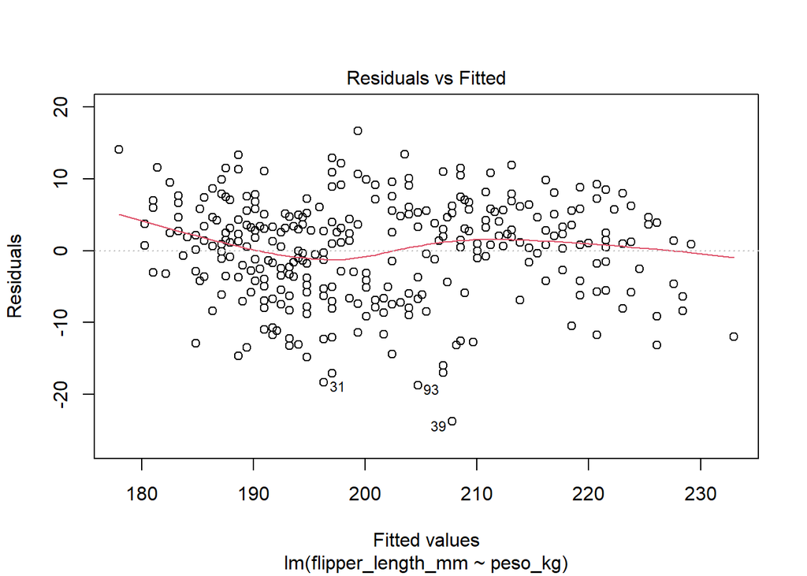

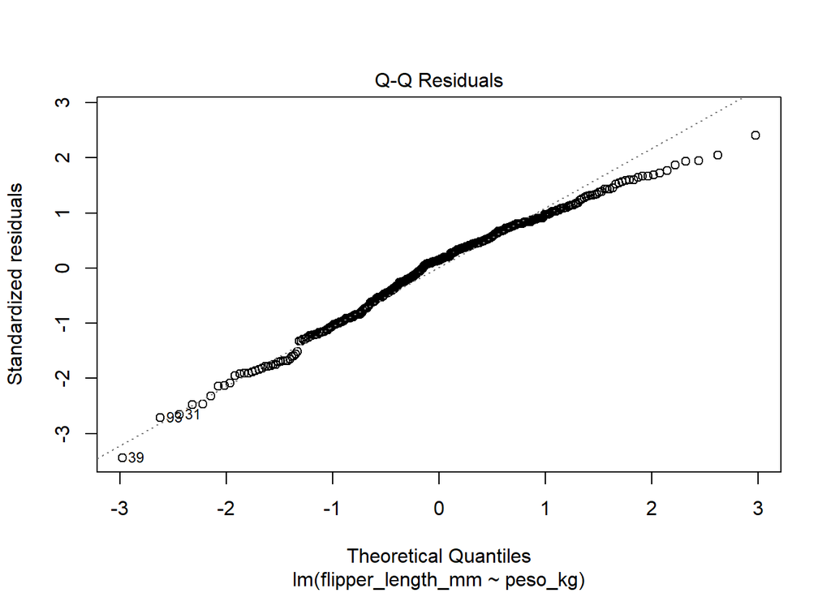

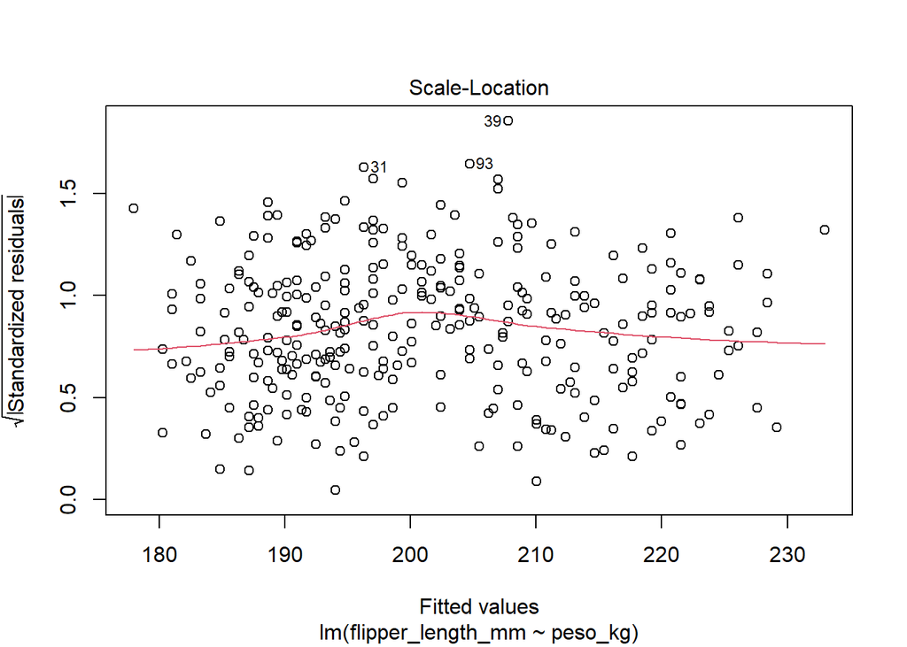

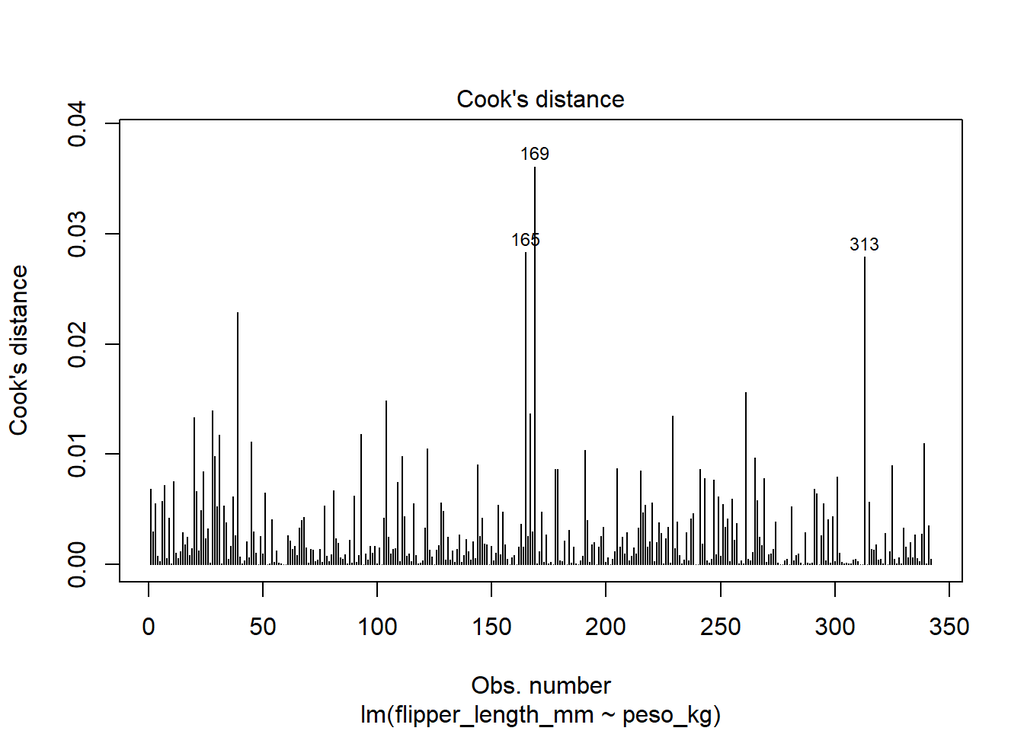

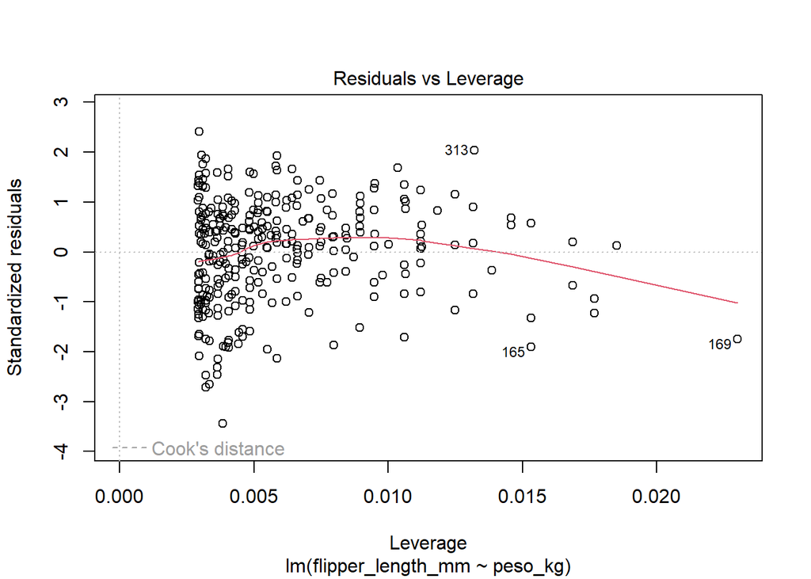

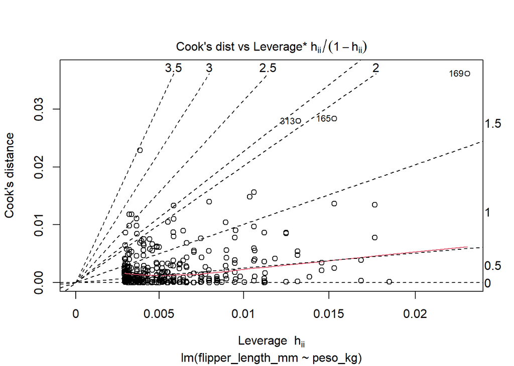

```r
plot(modelo1,
     which = c(1:6)) # para indicar que muestre todos los gráficos (6), por defecto muestra solo los primeros 4
```

El primer y tercer gráfico muestran la homogeneidad de la varianza de los residuales, el segundo gráfico muestra la normalidad de los residuales, y los últimos tres muestran los valores influyentes (outliers) basados en la distancia de Cook.

También podemos utilizar la función `check_model()` del paquete `performance`:

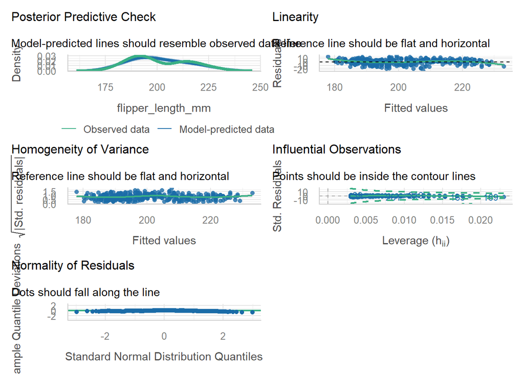

```r
check_model(modelo1)
```

El primer gráfico muestra las predicciones del modelo vs los valores observados, el segundo muestra la linealidad de los residuales, el tercero muestra la homogeneidad de la varianza de los residuales, el cuarto muestra las observaciones influyentes, y el quinto muestra la normalidad de los residuales.

Y podemos evaluar los supuestos de manera individual con algunas funciones del paquete `performance`.

Para evaluar la normalidad de los residuales utilizamos la función `check_normality()`:

```r
n <- check_normality(modelo1)
n
```

[output not shown]

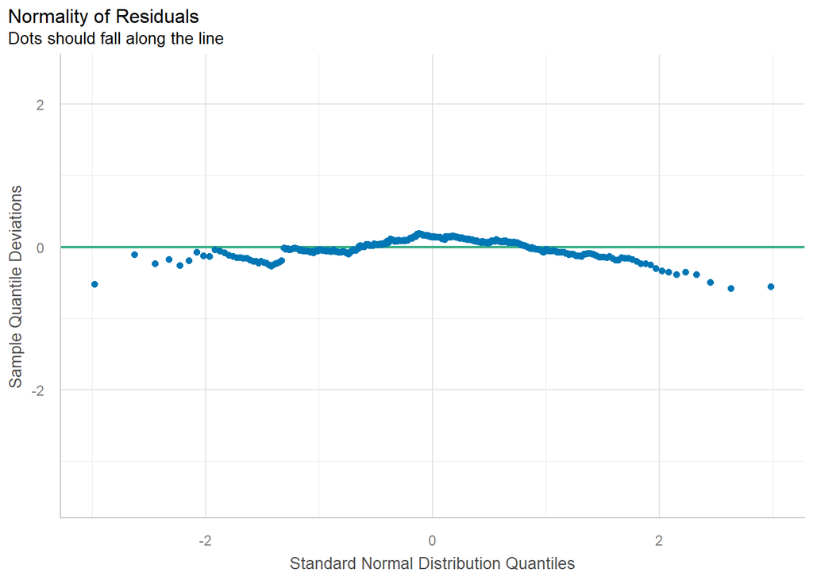

```r
plot(n)
```

Para evaluar la homogeneidad de la varianza de los residuales utilizamos la función `check_heteroscedasticity()` (cuando la variable predictora es numérica):

```r
h <- check_heteroscedasticity(modelo1)
h
```

```
## OK: Error variance appears to be homoscedastic (p = 0.922).
```

Nos dice de forma textual si la varianza de los residuales es homogénea

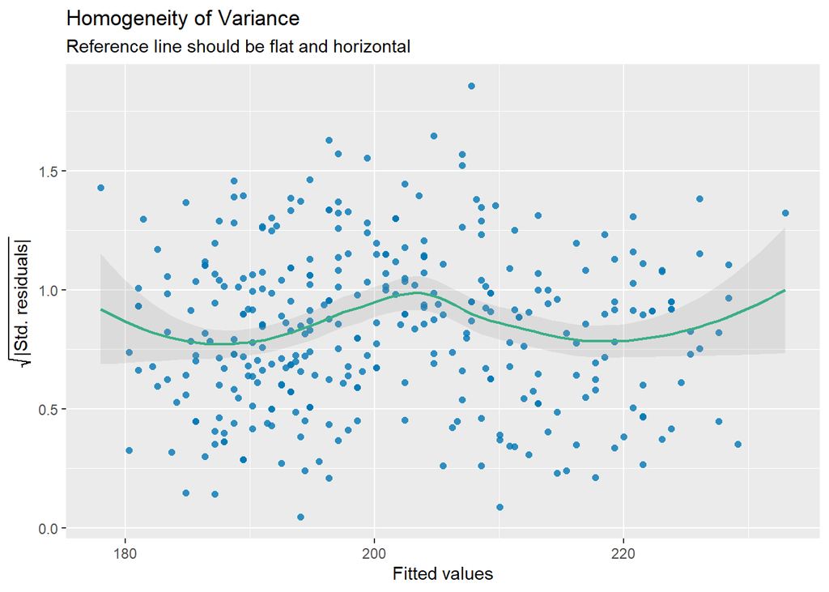

```r
plot(h)
```

En el gráfico no debemos notar ningún patrón, los puntos deben estar completamente dispersos para que haya homogeneidad de varianza (cuando la variable predictora es numérica). Si se ve un patrón de embudo con un agrupamiento de datos a la izquierda o a la derecha en el gráfico, la varianza de los residuales presenta problemas de heterogeneidad (no se mantiene constante).

Para evaluar las observaciones influyentes utilizamos la función `check_outliers()`:

```r
o <- check_outliers(modelo1)
o
```

```
## OK: No outliers detected.
## - Based on the following method and threshold: cook (0.7).
## - For variable: (Whole model)
```

Nos dice de forma textual si hay presencia de observaciones influyentes

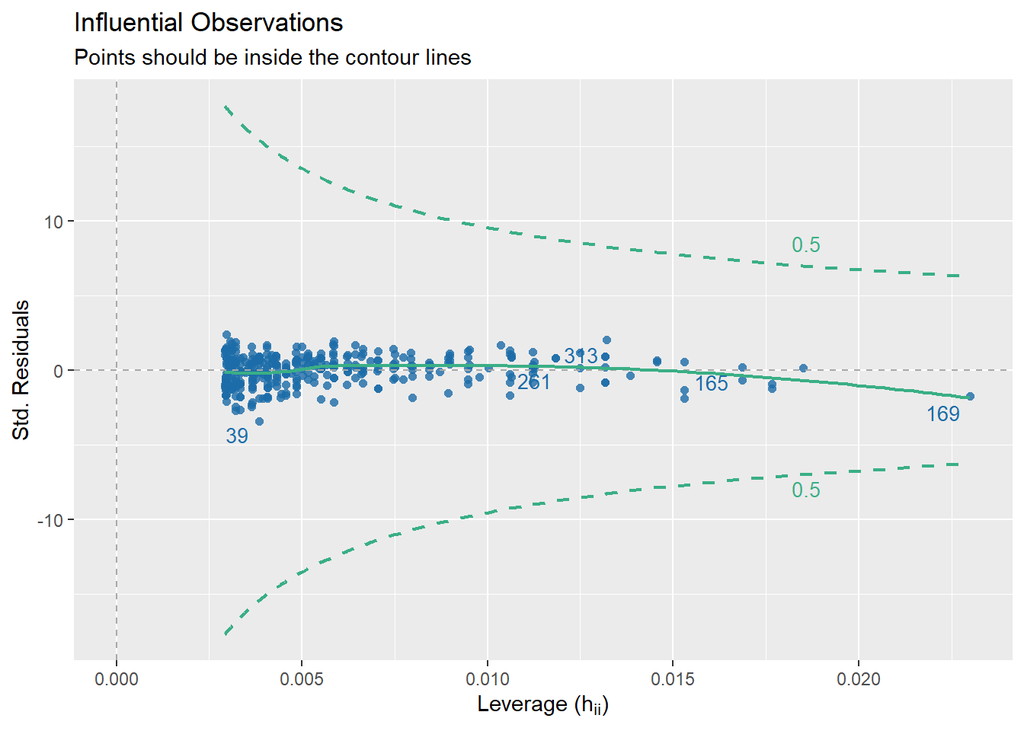

```r
plot(o)
```

Los valores deben mantenerse dentro las líneas punteadas de color verde, si hay valores influyentes se mostrarán fuera de las líneas punteadas.

Volver arriba

Inicio

#### Corrección del modelo

Cuando alguno de los supuestos no se cumple, podemos corregirlo de varias maneras.

- Si las variables no tienen una relación lineal podríamos ajustar modelos con variables transformadas (cuadráticas, cúbicas o logarítmicas) para tratar de ajustar la línea de predicción del modelo a nuestros datos.
- Si hay presencia de valores influyentes podemos ajustar un modelo eliminando esos valores de nuestra tabla de datos y verificar si hay una diferencia en los parámetros y el ajuste del modelo.
- Si los datos no son independientes, podemos ajustar modelos mixtos que toman en cuenta la jerarquía de las variables con parámetros fijos y aleatorios.
- Cuando el modelo no cumple con el supuesto de homogeneidad de la varianza podemos realizar una corrección o ajuste con la función `lm_robust()` del paquete `estimatr`:

```r
modelo1_r <- lm_robust(flipper_length_mm ~ peso_kg, data = p)
```

```r
summary(modelo1_r)
```

```
##
## Call:
## lm_robust(formula = flipper_length_mm ~ peso_kg, data = p)
##
## Standard error type:  HC2
##
## Coefficients:
##             Estimate Std. Error t value   Pr(>|t|) CI Lower CI Upper  DF
## (Intercept)   136.73     1.8442   74.14 5.632e-212   133.10   140.36 340
## peso_kg        15.28     0.4306   35.47 2.618e-116    14.43    16.12 340
##
## Multiple R-squared:  0.759 , Adjusted R-squared:  0.7583
## F-statistic:  1258 on 1 and 340 DF,  p-value: < 2.2e-16
```

Esto genera un modelo con errores estándar robustos para corregir la falta de homogeneidad de la varianza basado en los “heteroscedastic-consistent standard errors”, por defecto aplica la corrección de tipo `"HC2"`, pero podemos indicar un tipo específico con el argumento `se_type =`:

- `"HC0"`: (Heteroscedasticity-Consistent 0), usa los residuos al cuadrado sin ajustar por el tamaño de la muestra. Es más adecuado para muestras grandes.
- `"HC1"`: Variante de “HC0”, ajustada para tamaños de muestra más pequeños. Multiplica los errores estándar por $\frac{n}{n-k}$, donde $n$ es la muestra y $k$ los coeficientes.
- `"HC2"`: Corrige los residuos ponderándolos por la influencia de cada observación. Útil cuando hay observaciones con alto apalancamiento (cuánta influencia tiene una observación en el ajuste del modelo).
- `"HC3"`: Usa un ajuste de *jackknife* para reducir el sesgo. Es más conservador y funciona bien en muestras pequeñas.
- `"classical"`: Errores estándar sin ajuste (equivalente a `lm()`).
- `"CR0"` y `"CR2"`: Ajustes para datos con agrupamiento (observaciones no independientes).

Esta corrección no afecta los coeficientes del modelo (permanecen igual), pero los errores estándar e intervalos de confianza al 95% se ajustan a la falta de homogeneidad de varianza.

Parámetros de **modelo sin corregir**:

```
## Parameter   | Coefficient |     SE |               95% CI |  t(340) |      p
## ----------------------------------------------------------------------------
## (Intercept) |    136.7296 | 1.9968 | [132.8019, 140.6573] | 68.4731 | < .001
## peso kg     |     15.2759 | 0.4668 | [ 14.3577,  16.1942] | 32.7222 | < .001
```

Parámetros de **modelo corregido**:

```
## # Fixed Effects
##
## Parameter   | Coefficient |     SE |               95% CI |  t(340) |      p
## ----------------------------------------------------------------------------
## (Intercept) |    136.7296 | 1.8442 | [133.1021, 140.3570] | 74.1404 | < .001
## peso kg     |     15.2759 | 0.4306 | [ 14.4289,  16.1230] | 35.4722 | < .001
```

Volver arriba

Inicio

#### Gráfico del modelo

Con la función `plot_model()` del paquete `sjPlot`:

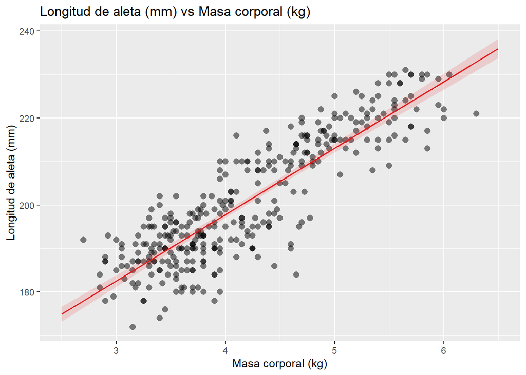

```r
plot_model(modelo1,
           type = "pred", # indicamos que es de tipo predictico ("pred")
           terms = "peso_kg", # argumento para indicar las variables predictoras
           show.data = TRUE, # para que muestre los valores observados
           title = "Longitud de aleta (mm) vs Masa corporal (kg)",
           axis.title = c("Masa corporal (kg)", "Longitud de aleta (mm)"))
```

Con la función `ggplot()` del paquete `ggplot2`:

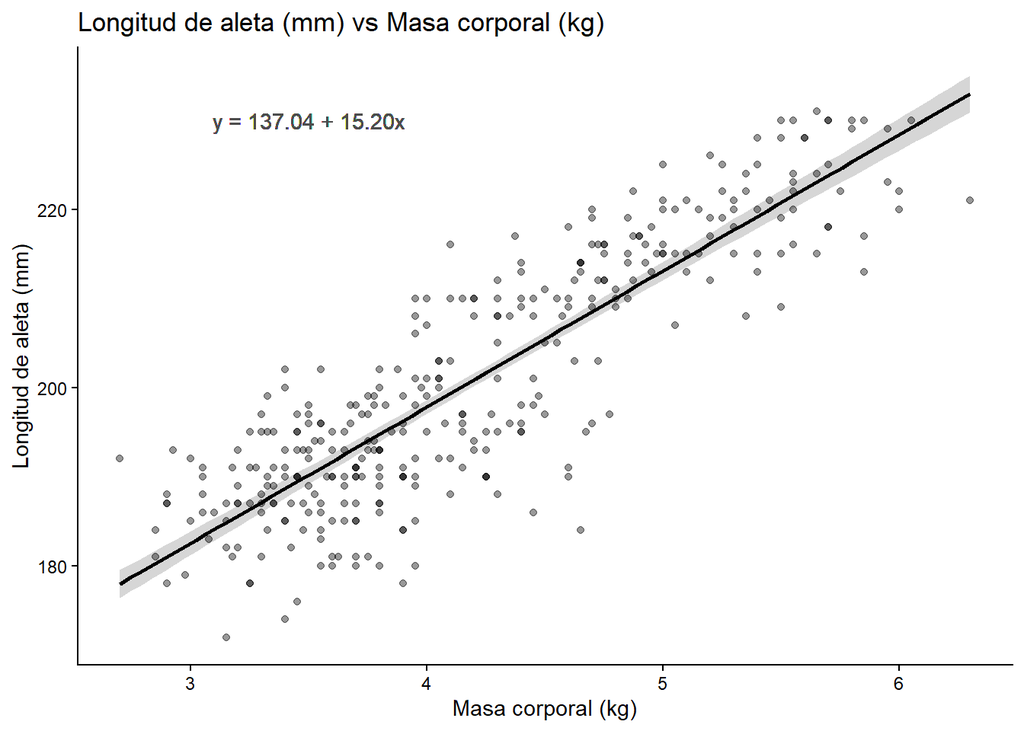

```r
ggplot(p, aes(peso_kg, flipper_length_mm)) +
  stat_smooth(color = "black",
              method = lm) + # para graficar la línea del modelo lineal
  geom_point(alpha = 0.4) +
  labs(title = "Longitud de aleta (mm) vs Masa corporal (kg)",
       y = "Longitud de aleta (mm)",
       x= "Masa corporal (kg)") +
  geom_text(aes(3.5,230), # para graficar la fórmula de la regresión lineal
            label = "y = 137.04 + 15.20x",
            color = "gray30") +
  theme_classic()
```

Volver arriba

Inicio